# MaxDiff Analysis of MSBA Class Preferences

Counts · MLE · Bayesian Estimation of the MNL Model

Fancheng Xia

2026-06-04

## What is MaxDiff?

**The problem with rating scales**

- Respondents use Likert scales inconsistently — one person’s “7” is another’s “9”
- No forced differentiation: everything ends up rated highly

**MaxDiff (Best-Worst Scaling)**

- Each screen: see **4 items**, pick **most** and **least** preferred
- Forces real trade-offs → more reliable, comparable preferences

**This study:** 10 MSBA core courses · 85 respondents · 8 tasks each

## Three Methods, One Question

> *Which MSBA courses do students prefer most?*

**① Counts**

$$\text{score}_j = \%\text{best}_j - \%\text{worst}_j$$

Fast · transparent · zero modeling assumptions

**② MNL via MLE**

$$P(\text{best}=j) = \frac{e^{\beta_j}}{\sum_k e^{\beta_k}}$$

Accounts for competitive context · standard errors

**③ MNL via Bayes**

$$\pi(\beta \mid y) \propto L(\beta)\,\pi(\beta)$$

Full posterior → uncertainty on derived quantities

Each method adds something the previous one lacks.

## Results: All Three Methods Agree

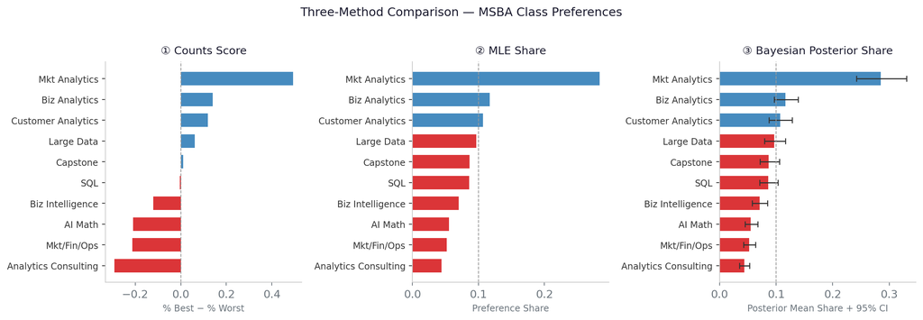

## When to Use Each Method

| Method | Best for | Key limitation |
| --- | --- | --- |
| **Counts** | Quick first pass, executive summary | Ignores competitive context |
| **MLE** | Point estimate + standard errors | CIs on derived quantities need delta method |
| **Bayes** | Uncertainty on shares, downstream decisions | Computationally heavier |

**The Bayesian advantage in one sentence:**

> Push every MCMC draw through softmax → credible intervals on preference shares, *for free* — no delta method required.

**Next step →** Hierarchical Bayes: individual-level $\beta_i$ to find preference *segments* (tech vs. finance vs. consulting track).